# Data Handling: Import, Cleaning and Visualisation

## Stack/row-bind

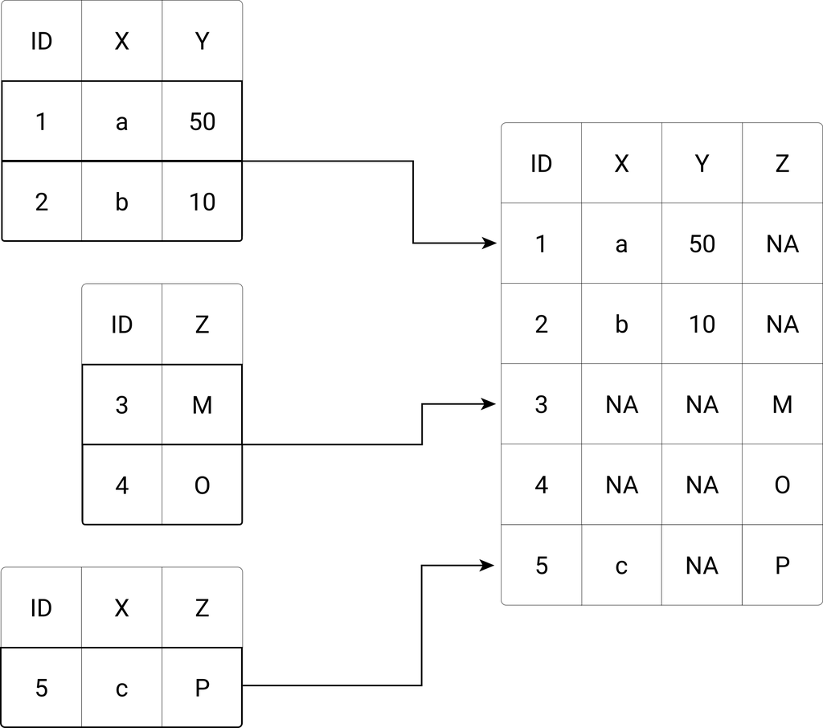

# Code Examples

## Cleaning variables

We first load this package as we rely on functions provided in the `tidyverse`.

```r
library(tidyverse)
```

Initiate a stylistic example of a “messy” data frame:

```r
messy_df <- data.frame(last_name = c("Wayne", "Trump", "Karl Marx"),
                       first_name = c("John", "Melania", ""),
                       gender = c("male", "female", "Man"),
                       date = c("2018-11-15", "2018.11.01", "2018/11/02"),
                       income = c("150,000", "250000", "10000"),
                       stringsAsFactors = FALSE)
```

### Find/replace character strings, recode factor levels

Recall that categorical variables are best stored as factors:

```r
messy_df$gender <- as.factor(messy_df$gender)
messy_df$gender
```

```
## [1] male   female Man
## Levels: female male Man
```

R defined the factor variable such that an observation can be one of three categories (‘levels’): `female`, `male`, or `Man`. The underlying data needs to be cleaned:

```r
messy_df$gender[messy_df$gender == "Man"] <- "male"
messy_df$gender
```

```
## [1] male   female male
## Levels: female male Man
```

Use `fct_recode()` (provided in `tidyverse`), to update/recode the factor variable.

```r
messy_df$gender <- fct_recode(messy_df$gender, "male" = "Man")
messy_df$gender
```

```
## [1] male   female male
## Levels: female male
```

### Removing individual characters from a string

The `income` column contains numbers, so let’s try to set this column to type `integer`.

```r
as.integer(messy_df$income)
```

```
## [1]     NA 250000  10000
```

The value containing a comma `,` could not be coerced to an integer value. We need to clean it first by “removing” the comma from the underlying string (i.e., replace the part of the string `","` with nothing `""`).

```r
messy_df$income <- str_replace(messy_df$income, pattern = ",", replacement = "")
```

Now we can successfully set the column as type integer.

```r
messy_df$income <- as.integer(messy_df$income)
```

### Splitting strings

From looking at the `last_name` and `first_name` columns of our messy dataset, it becomes clear that the last row is not accurately coded. To re-code these variables correctly, we can use the function `str_split()`. First, we split the strings at every occurrence of white space (`" "`). Setting the option `simplify=TRUE`, we get a matrix containing the individual sub-strings after the splitting.

```r
splitnames <- str_split(messy_df$last_name, pattern = " ", simplify = TRUE)
splitnames
```

```
##      [,1]    [,2]
## [1,] "Wayne" ""
## [2,] "Trump" ""
## [3,] "Karl"  "Marx"
```

In a second step, we replace empty observations in the `first_name` column with the corresponding values in `splitnames`.

```r
problem_cases <- messy_df$first_name == ""
messy_df$first_name[problem_cases] <- splitnames[problem_cases, 1]
```

Finally, we must correct the `last_name` column by replacing the respective values.

```r
messy_df$last_name[problem_cases] <- splitnames[problem_cases, 2]
messy_df
```

```
##   last_name first_name gender       date income
## 1     Wayne       John   male 2018-11-15 150000
## 2     Trump    Melania female 2018.11.01 250000
## 3      Marx       Karl   male 2018/11/02  10000
```

### Parsing dates

The `date`-column uses no unique standard for dates. We can use the `ymd()`-function provided in the `lubridate`-package to parse the column as `Date` type.

```r
library(lubridate)
messy_df$date <- ymd(messy_df$date)
```

Note how this function automatically recognizes how different special characters have been used in different observations to separate years from months/days.

Now, our dataset is cleaned up and ready to go.

```r
messy_df
```

```
##   last_name first_name gender       date income
## 1     Wayne       John   male 2018-11-15 150000
## 2     Trump    Melania female 2018-11-01 250000
## 3      Marx       Karl   male 2018-11-02  10000
```

```r
str(messy_df)
```

```
## 'data.frame':    3 obs. of  5 variables:
##  $ last_name : chr  "Wayne" "Trump" "Marx"
##  $ first_name: chr  "John" "Melania" "Karl"
##  $ gender    : Factor w/ 2 levels "female","male": 2 1 2
##  $ date      : Date, format: "2018-11-15" "2018-11-01" "2018-11-02"
##  $ income    : int  150000 250000 10000
```

# Reshaping datasets

### Pivoting from ‘wide to long’

To illustrate how *pivoting from wide to long* works in practice, consider the following example dataset (extending on the example above).

```r
wide_df <- data.frame(last_name = c("Wayne", "Trump", "Marx"),
                       first_name = c("John", "Melania", "Karl"),
                       gender = c("male", "female", "male"),
                       income.2018 = c("150000", "250000", "10000"),
                      income.2017 = c( "140000", "230000", "15000"),
                      stringsAsFactors = FALSE)
wide_df
```

```
##   last_name first_name gender income.2018 income.2017
## 1     Wayne       John   male      150000      140000
## 2     Trump    Melania female      250000      230000
## 3      Marx       Karl   male       10000       15000
```

To reshape this data frame from wide to long (regarding the `income`-variable), we can use `pivot_longer()` as follows.

```r
long_df <- pivot_longer(wide_df, c(income.2018, income.2017),
                        names_to = "year",
                        names_prefix ="income.",
                        values_to = "income")
long_df
```

```
## # A tibble: 6 × 5
##   last_name first_name gender year  income
##   <chr>     <chr>      <chr>  <chr> <chr>
## 1 Wayne     John       male   2018  150000
## 2 Wayne     John       male   2017  140000
## 3 Trump     Melania    female 2018  250000
## 4 Trump     Melania    female 2017  230000
## 5 Marx      Karl       male   2018  10000
## 6 Marx      Karl       male   2017  15000
```

### Pivoting from ‘long to wide’ (“spreading”)

```r
weird_df <- data.frame(last_name = c("Wayne", "Trump", "Marx",
                                     "Wayne", "Trump", "Marx",
                                     "Wayne", "Trump", "Marx"),
                       first_name = c("John", "Melania", "Karl",
                                      "John", "Melania", "Karl",
                                      "John", "Melania", "Karl"),
                       gender = c("male", "female", "male",
                                  "male", "female", "male",
                                  "male", "female", "male"),
                       value = c("150000", "250000", "10000",
                                 "2000000", "5000000", "NA",
                                 "50", "25", "NA"),
                       variable = c("income", "income", "income",
                                    "assets", "assets", "assets",
                                    "age", "age", "age"),
                       stringsAsFactors = FALSE)
weird_df
```

```
##   last_name first_name gender   value variable
## 1     Wayne       John   male  150000   income
## 2     Trump    Melania female  250000   income
## 3      Marx       Karl   male   10000   income
## 4     Wayne       John   male 2000000   assets
## 5     Trump    Melania female 5000000   assets
## 6      Marx       Karl   male      NA   assets
## 7     Wayne       John   male      50      age
## 8     Trump    Melania female      25      age
## 9      Marx       Karl   male      NA      age
```

We can call the function `pivot_wider()` with the two parameters `names` and `value` to transform the data frame from long to vide as follows.

```r
tidy_df <- pivot_wider(weird_df, names_from = "variable", values_from = "value")
tidy_df
```

```
## # A tibble: 3 × 6
##   last_name first_name gender income assets  age
##   <chr>     <chr>      <chr>  <chr>  <chr>   <chr>
## 1 Wayne     John       male   150000 2000000 50
## 2 Trump     Melania    female 250000 5000000 25
## 3 Marx      Karl       male   10000  NA      NA
```

## Stacking/row-binding datasets

Create three separate subsets that can be combined into one larger dataset (data frame/tibble).

```r
# initialize sample data
subset1 <- data.frame(ID=c(1,2),
                      X=c("a", "b"),
                      Y=c(50,10))

subset2 <- data.frame(ID=c(3,4),
                      Z=c("M", "O"))

subset3 <- data.frame(ID= c(5),
                      X=c("c"),
                      Z="P")
```

To stack the three subsets together, we call `bind_rows()` as follows (`dplyr` needs to be installed and loaded for this).

```r
# install if needed
# install.packages("dplyr")

# load packages
library(dplyr)

# stack data frames
combined_df <- bind_rows(subset1, subset2, subset3)

# inspect the result
combined_df
```

```
##   ID    X  Y    Z
## 1  1    a 50 <NA>
## 2  2    b 10 <NA>
## 3  3 <NA> NA    M
## 4  4 <NA> NA    O
## 5  5    c NA    P
```

Note how `bind_rows()` automatically matches the column names (orders the columns before stacking), and fills missing values with `NA`s (not available).

# References

Wickham, Hadley. 2014. “Tidy Data.” *Journal of Statistical Software* 59 (10): 1–23. https://doi.org/10.18637/jss.v059.i10.